# Modeling

Daniel Anderson

This doc is for sharing the modeling I’ve done so far.

# Research Questions

1. To what extent do achievement disparities between students who are and are not classified as economically disadvantaged vary between schools?
2. To what extent do these achievement disparities change over time?
3. To what extent do absenteeism rates for students who are and are not classified as economically disadvantaged vary between schools?
4. Are observed achievement disparities, and trends in achievement disparities, moderated by absenteeism rates?
5. Do school-level absenteeism rates, and disproportionality in absenteeism rates between students who are and are not classified as economically disadvantaged, relate to the school-level (average) achievement disparity?

## Preliminary stuff

I wanted to start by exploring the trajectories over time a bit. I was particularly interested in the functional form. The below makes it pretty clear that a cubic fit is following the means at each time point near perfectly.

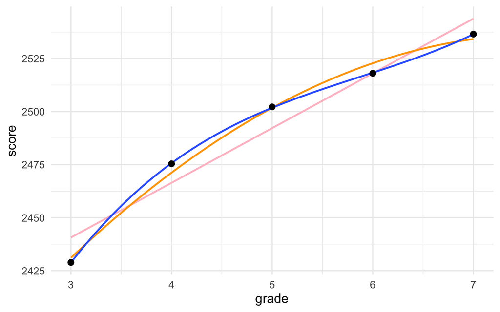

```r
d <- readr::read_csv(here::here("data", "analytic-sample.csv"))

#### Plots
d |>
  group_by(grade) |>
  summarize(score = mean(rit_tot, na.rm = TRUE)) |>
  ggplot(aes(grade, score)) +
  geom_smooth(
    method = "lm",
    color = "pink",
    se = FALSE
  ) +
  geom_smooth(
    method = "lm",
    color = "orange",
    formula = y ~ poly(x, 2),
    se = FALSE
  ) +
  geom_smooth(
    method = "lm",
    formula = y ~ poly(x, 3),
    se = FALSE
  ) +
  geom_point(size = 3)
```

So I expect to move forward with a cubic model. Let’s see how this looks by group, however.

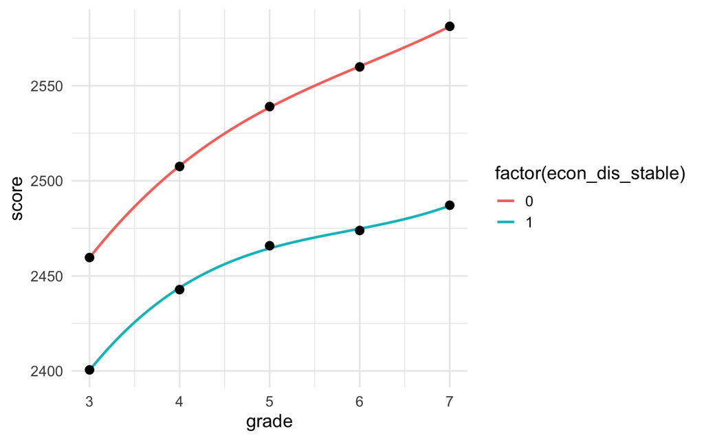

```r
d |>
  group_by(grade, econ_dis_stable) |>
  summarize(score = mean(rit_tot, na.rm = TRUE)) |>
  ggplot(aes(grade, score)) +
  geom_smooth(
    aes(color = factor(econ_dis_stable)),
    method = "lm",
    formula = y ~ poly(x, 3),
    se = FALSE
  ) +
  geom_point(
    aes(group = factor(econ_dis_stable)),
    size = 3
  )
```

# Modeling

## Unconditional growth model

I started out by fittin a linear model

```r
m0 <- lmer(
  rit_tot ~ wave +
    (wave | ssid) + (wave | schid),
  data = d,
  control = lmerControl(optimizer = "bobyqa"),
  REML = FALSE
)
```

I then compared the fit of this model with a curvillinear cubic model.

```r
m01 <- lmer(
  rit_tot ~ poly(wave, 3) +
    (wave | ssid) + (wave | schid),
  data = d,
  control = lmerControl(optimizer = "bobyqa"),
  REML = FALSE
)

# polynomial model clearly fits better, unsurprisingly
anova(m0, m01)
```

```
## Data: d
## Models:
## m0: rit_tot ~ wave + (wave | ssid) + (wave | schid)
## m01: rit_tot ~ poly(wave, 3) + (wave | ssid) + (wave | schid)
##     npar     AIC     BIC  logLik deviance Chisq Df Pr(>Chisq)
## m0     9 1388653 1388741 -694317  1388635
## m01   11 1386813 1386920 -693395  1386791  1844  2  < 2.2e-16 ***
## ---
## Signif. codes:  0 '***' 0.001 '**' 0.01 '*' 0.05 '.' 0.1 ' ' 1
```

```r
summary(m01)
```

```
## Linear mixed model fit by maximum likelihood  ['lmerMod']
## Formula: rit_tot ~ poly(wave, 3) + (wave | ssid) + (wave | schid)
##    Data: d
## Control: lmerControl(optimizer = "bobyqa")
##
##       AIC       BIC    logLik  deviance  df.resid
## 1386812.8 1386920.2 -693395.4 1386790.8    127912
##
## Scaled residuals:
##      Min       1Q   Median       3Q      Max
## -10.2035  -0.4338   0.0059   0.4591   9.4940
##
## Random effects:
##  Groups   Name        Variance Std.Dev. Corr
##  ssid     (Intercept) 4757.4   68.97
##           wave         212.7   14.58    0.41
##  schid    (Intercept)  699.6   26.45
##           wave         104.7   10.23    -0.60
##  Residual             1010.4   31.79
## Number of obs: 127923, groups:  ssid, 39721; schid, 649
##
## Fixed effects:
##                Estimate Std. Error t value
## (Intercept)     2489.59       1.03 2416.25
## poly(wave, 3)1 13824.99     241.39   57.27
## poly(wave, 3)2 -2603.21      78.19  -33.29
## poly(wave, 3)3   863.38      50.18   17.20
##
## Correlation of Fixed Effects:
##             (Intr) p(,3)1 p(,3)2
## poly(wv,3)1  0.198
## poly(wv,3)2  0.183  0.139
## poly(wv,3)3  0.072 -0.060  0.297
```

The cubic model clearly fits better, so we’ll go forward with that. This model only allows the linear piece to randomly vary across schools. I don’t think it’s worth trying to model the bends in the curve as randomly varying.

We might interpret this model with something like:

> The curvillinear cubic model clearly fit the data better than the linear model (cite stats). We allowed the intercept and the linear piece of the growth model to vary randomly across both students and schools. This models different starting points (initial achievment) for students and schools (average initial achievement), as well as different trajectories for each student and average trajectories for each school. However, because we did not allow the curvillinear parts to vary randomly, the functional form of the growth (bends in the curve) was common across students and schools.

I can make the plot prettier, but a draft is below. I’m also not positive what plots we’ll end up wanting to include. I also am not sure this is the best plot to show the curvilinearity

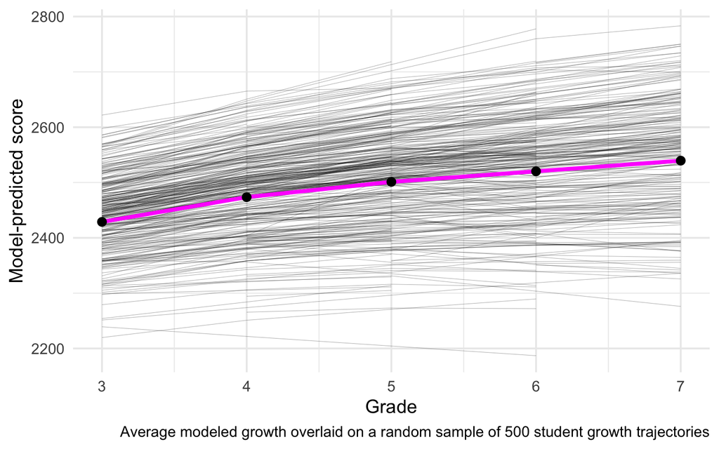

```r
set.seed(123)
students <- sample(unique(m01@frame$ssid), 500)
stu_pred <- d |>
  filter(ssid %in% students)

stu_pred <- stu_pred |>
  mutate(pred = predict(m01, newdata = stu_pred))

fixef_pred <- tibble(
  wave = 0:4,
  ssid = -999,
  schid = -999
)
fixef_pred <- fixef_pred |>
  mutate(pred = predict(m01, newdata = fixef_pred, allow.new.levels = TRUE))

ggplot(stu_pred, aes(grade, pred)) +
  geom_line(
    aes(group = ssid),
    alpha = 0.6,
    size = 0.1
  ) +
  geom_line(
    aes(x = wave + 3),
    fixef_pred,
    color = "magenta",
    size = 1.5
  ) +
  geom_point(
    aes(x = wave + 3),
    fixef_pred,
    size = 3
  ) +
  labs(
    x = "Grade",
    y = "Model-predicted score",
    caption = "Average modeled growth overlaid on a random sample of 500 student growth trajectories"
  )
```

Below is another probably better plot that shows the same thing but with 100 school trajectories overlaid instead.

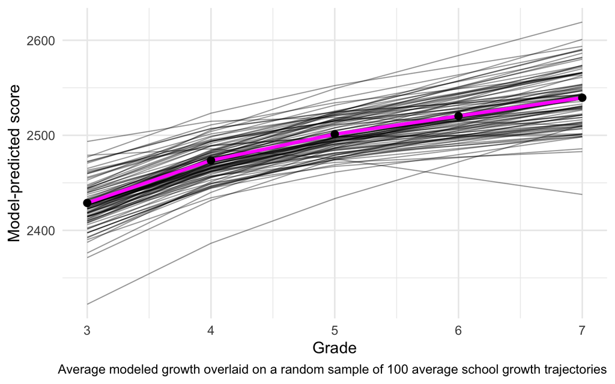

```r
schools <- sample(unique(m01@frame$schid), 100)

sch_only <- expand.grid(
  schid = schools,
  ssid = -999,
  wave = 0:4
)

sch_only <- sch_only |>
  mutate(pred = predict(m01, newdata = sch_only, allow.new.levels = TRUE))

ggplot(sch_only, aes(wave + 3, pred)) +
  geom_line(
    aes(group = schid),
    alpha = 0.4
  ) +
  geom_line(
    aes(x = wave + 3),
    fixef_pred,
    color = "magenta",
    size = 1.5
  ) +
    geom_point(
      aes(x = wave + 3),
      fixef_pred,
      size = 3
    ) +
    labs(
      x = "Grade",
      y = "Model-predicted score",
      caption = "Average modeled growth overlaid on a random sample of 100 average school growth trajectories"
    )
```

And one more possible one, although this one definitely needs some work. We could get a sample of schools and show the variation in growth trajectories for those schools. I should probably cutoff the prediction when there’s no data in that range.

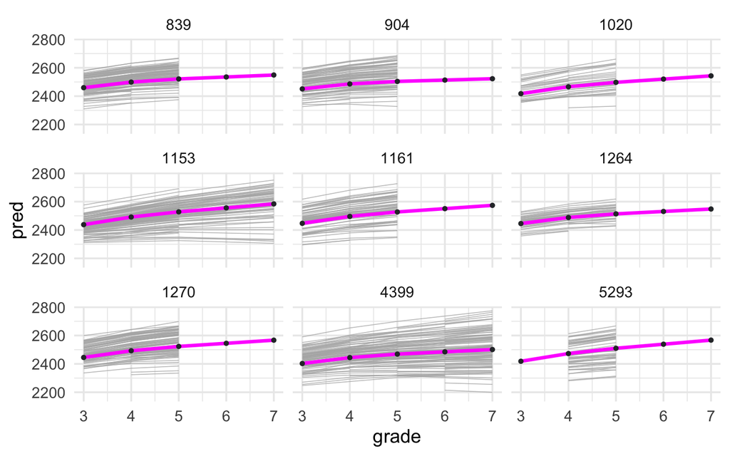

```r
schls <- d |>
  count(schid, grade) |>
  count(schid) |>
  filter(n > 1)

schls <- d |>
  filter(schid %in% schls$schid) |>
  count(schid, ssid) |>
  count(schid, sort = TRUE) |>
  slice(c(2, seq(50, 400, 50))) |>
  pull(schid)

schl_sample <- d |>
  filter(schid %in% schls & ssid %in% m01@frame$ssid)

schl_sample$pred <- predict(m01, newdata = schl_sample)
schl_preds <- expand.grid(
  schid = schls,
  ssid = -999,
  wave = 0:4
)
schl_preds$pred <- predict(m01, newdata = schl_preds, allow.new.levels = TRUE)

ggplot(schl_sample, aes(grade, pred)) +
  geom_line(
    aes(group = ssid),
    size = 0.3,
    alpha = 0.8,
    color = "gray70"
  ) +
  geom_line(
    aes(x = wave + 3),
    color = "magenta",
    size = 1.3,
    data = schl_preds
  ) +
  geom_point(
    aes(x = wave + 3),
    color = "#2d3035",
    size = 1.3,
    data = schl_preds
  ) +
  facet_wrap(~schid)
```

## Economically-based achievement disparities

I first modeled the average disparity, then allowed that disparity to vary by school. The model that allowed the disparity to vary between schools clearly fit the data better than the model that included only the mean difference, and both models clearly fit better than the unconditional growth model.

### Average disparity

```r
# add economically disadvantaged
m1 <- lmer(
  rit_tot ~ poly(wave, 3) + econ_dis_stable +
    (wave | ssid) + (wave | schid),
  data = d,
  control = lmerControl(optimizer = "bobyqa"),
  REML = FALSE
)
anova(m01, m1) # clearly better
```

```
## Data: d
## Models:
## m01: rit_tot ~ poly(wave, 3) + (wave | ssid) + (wave | schid)
## m1: rit_tot ~ poly(wave, 3) + econ_dis_stable + (wave | ssid) + (wave | schid)
##     npar     AIC     BIC  logLik deviance  Chisq Df Pr(>Chisq)
## m01   11 1386813 1386920 -693395  1386791
## m1    12 1382447 1382564 -691212  1382423 4367.7  1  < 2.2e-16 ***
## ---
## Signif. codes:  0 '***' 0.001 '**' 0.01 '*' 0.05 '.' 0.1 ' ' 1
```

```r
summary(m1)
```

```
## Linear mixed model fit by maximum likelihood  ['lmerMod']
## Formula: rit_tot ~ poly(wave, 3) + econ_dis_stable + (wave | ssid) + (wave |
##     schid)
##    Data: d
## Control: lmerControl(optimizer = "bobyqa")
##
##       AIC       BIC    logLik  deviance  df.resid
## 1382447.1 1382564.2 -691211.6 1382423.1    127911
##
## Scaled residuals:
##      Min       1Q   Median       3Q      Max
## -10.2741  -0.4371   0.0079   0.4619   9.4947
##
## Random effects:
##  Groups   Name        Variance Std.Dev. Corr
##  ssid     (Intercept) 4240.9   65.12
##           wave         208.9   14.45    0.35
##  schid    (Intercept)  567.5   23.82
##           wave         101.0   10.05    -0.62
##  Residual             1008.4   31.76
## Number of obs: 127923, groups:  ssid, 39721; schid, 649
##
## Fixed effects:
##                   Estimate Std. Error t value
## (Intercept)      2516.2464     1.0187 2470.08
## poly(wave, 3)1  13807.4396   236.0008   58.51
## poly(wave, 3)2  -2585.9131    77.0035  -33.58
## poly(wave, 3)3    872.9791    49.4478   17.66
## econ_dis_stable   -53.8142     0.7888  -68.22
##
## Correlation of Fixed Effects:
##             (Intr) p(,3)1 p(,3)2 p(,3)3
## poly(wv,3)1  0.228
## poly(wv,3)2  0.186  0.144
## poly(wv,3)3  0.069 -0.059  0.280
## ecn_ds_stbl -0.382 -0.001 -0.005 -0.003
```

### RQ 1

```r
# Model between-school variance in the average disparity
m2 <- lmer(
  rit_tot ~ poly(wave, 3) + econ_dis_stable +
    (wave | ssid) + (wave + econ_dis_stable | schid),
  data = d,
  control = lmerControl(optimizer = "bobyqa"),
  REML = FALSE
)
anova(m1, m2)
```

```
## Data: d
## Models:
## m1: rit_tot ~ poly(wave, 3) + econ_dis_stable + (wave | ssid) + (wave | schid)
## m2: rit_tot ~ poly(wave, 3) + econ_dis_stable + (wave | ssid) + (wave + econ_dis_stable | schid)
##    npar     AIC     BIC  logLik deviance  Chisq Df Pr(>Chisq)
## m1   12 1382447 1382564 -691212  1382423
## m2   15 1381780 1381926 -690875  1381750 673.17  3  < 2.2e-16 ***
## ---
## Signif. codes:  0 '***' 0.001 '**' 0.01 '*' 0.05 '.' 0.1 ' ' 1
```

```r
summary(m2)
```

```
## Linear mixed model fit by maximum likelihood  ['lmerMod']
## Formula: rit_tot ~ poly(wave, 3) + econ_dis_stable + (wave | ssid) + (wave +
##     econ_dis_stable | schid)
##    Data: d
## Control: lmerControl(optimizer = "bobyqa")
##
##      AIC      BIC   logLik deviance df.resid
##  1381780  1381926  -690875  1381750   127908
##
## Scaled residuals:
##     Min      1Q  Median      3Q     Max
## -9.9132 -0.4372  0.0079  0.4617  9.3076
##
## Random effects:
##  Groups   Name            Variance Std.Dev. Corr
##  ssid     (Intercept)     4191.6   64.74
##           wave             200.3   14.15    0.36
##  schid    (Intercept)      683.6   26.15
##           wave             102.3   10.11    -0.59
##           econ_dis_stable  209.5   14.47    -0.47  0.11
##  Residual                 1005.0   31.70
## Number of obs: 127923, groups:  ssid, 39721; schid, 649
##
## Fixed effects:
##                  Estimate Std. Error t value
## (Intercept)      2517.186      1.097 2295.45
## poly(wave, 3)1  13759.584    236.677   58.14
## poly(wave, 3)2  -2519.006     76.693  -32.84
## poly(wave, 3)3    910.769     49.233   18.50
## econ_dis_stable   -56.082      1.007  -55.70
##
## Correlation of Fixed Effects:
##             (Intr) p(,3)1 p(,3)2 p(,3)3
## poly(wv,3)1  0.192
## poly(wv,3)2  0.174  0.145
## poly(wv,3)3  0.064 -0.058  0.276
## ecn_ds_stbl -0.521  0.055 -0.009 -0.006
```

This model can be used to address RQ1. We might say something like:

> Students classified by the Oregon Department of Education as “economically disadvantaged” scored approximately 56 points lower on the statewide assessment than their peers who were not classified. This represents approximately 0.70 standard deviations on the mathematics statewide test in Grade 3, and 0.47 standard deviations on the Grade 7 statewide test. This mean difference, however, varied considerably between schools with a standard deviation of 14.47. The achievement disparity in a school one standard deviation above the mean would therefore be approximately 70 points, while a school one standard deviation below the mean would be approximately 42 points (roughly half a standard deviation difference versus 0.89 standard deviations difference, at Grade 3). This was consistent with our hypothesis.

Below are the effect-size like metrics I reference from above.

```r
d |>
  group_by(grade) |>
  summarize(sd = sd(rit_tot, na.rm = TRUE)) |>
  mutate(
    es = abs(fixef(m2)["econ_dis_stable"]) / sd,
    above = (abs(fixef(m2)["econ_dis_stable"]) + 14.47) / sd,
    below = (abs(fixef(m2)["econ_dis_stable"]) - 14.47) / sd,
  )
```

```
## # A tibble: 5 x 5
##   grade        sd        es     above     below
##   <dbl>     <dbl>     <dbl>     <dbl>     <dbl>
## 1     3  79.36888 0.7066000 0.8889132 0.5242867
## 2     4  82.35289 0.6809967 0.8567040 0.5052894
## 3     5  93.84373 0.5976110 0.7518035 0.4434185
## 4     6 111.4238  0.5033220 0.6331865 0.3734574
## 5     7 118.8195  0.4719935 0.5937748 0.3502122
```

### RQ 2

To address the second research question - how do these disparities change over time - we model the interaction between economically disadvantaged status and wave.

```r
m3 <- lmer(
  rit_tot ~ poly(wave, 3) + econ_dis_stable + econ_dis_stable:wave +
    (wave | ssid) + (wave + econ_dis_stable | schid),
  data = d,
  control = lmerControl(optimizer = "nlminbwrap"),
  REML = FALSE
)
anova(m2, m3)
```

```
## Data: d
## Models:
## m2: rit_tot ~ poly(wave, 3) + econ_dis_stable + (wave | ssid) + (wave + econ_dis_stable | schid)
## m3: rit_tot ~ poly(wave, 3) + econ_dis_stable + econ_dis_stable:wave + (wave | ssid) + (wave + econ_dis_stable | schid)
##    npar     AIC     BIC  logLik deviance  Chisq Df Pr(>Chisq)
## m2   15 1381780 1381926 -690875  1381750
## m3   16 1381402 1381558 -690685  1381370 379.76  1  < 2.2e-16 ***
## ---
## Signif. codes:  0 '***' 0.001 '**' 0.01 '*' 0.05 '.' 0.1 ' ' 1
```

We see again that the model including this interaction clearly fits better. However, I was also interested to if the curvillinear parts depended on group membership.

```r
m3b <- lmer(
  rit_tot ~ poly(wave, 3) * econ_dis_stable +
    (wave | ssid) + (wave + econ_dis_stable | schid),
  data = d,
  control = lmerControl(optimizer = "nlminbwrap"),
  REML = FALSE
)
anova(m3, m3b)
```

```
## Data: d
## Models:
## m3: rit_tot ~ poly(wave, 3) + econ_dis_stable + econ_dis_stable:wave + (wave | ssid) + (wave + econ_dis_stable | schid)
## m3b: rit_tot ~ poly(wave, 3) * econ_dis_stable + (wave | ssid) + (wave + econ_dis_stable | schid)
##     npar     AIC     BIC  logLik deviance  Chisq Df Pr(>Chisq)
## m3    16 1381402 1381558 -690685  1381370
## m3b   18 1381340 1381515 -690652  1381304 66.479  2  3.666e-15 ***
## ---
## Signif. codes:  0 '***' 0.001 '**' 0.01 '*' 0.05 '.' 0.1 ' ' 1
```

and we see that it does. So it’s not only the slope, but also the functional form (bends in the curve) that depend on economic disadvantaged status. We’ll go forward with this model.

```r
summary(m3b)
```

```
## Linear mixed model fit by maximum likelihood  ['lmerMod']
## Formula: rit_tot ~ poly(wave, 3) * econ_dis_stable + (wave | ssid) + (wave +
##     econ_dis_stable | schid)
##    Data: d
## Control: lmerControl(optimizer = "nlminbwrap")
##
##       AIC       BIC    logLik  deviance  df.resid
## 1381339.7 1381515.4 -690651.9 1381303.7    127905
##
## Scaled residuals:
##     Min      1Q  Median      3Q     Max
## -9.9723 -0.4369  0.0078  0.4609  9.3624
##
## Random effects:
##  Groups   Name            Variance Std.Dev. Corr
##  ssid     (Intercept)     4193.4   64.76
##           wave             198.7   14.10    0.37
##  schid    (Intercept)      659.1   25.67
##           wave             100.8   10.04    -0.60
##           econ_dis_stable  109.8   10.48    -0.43  0.05
##  Residual                 1003.5   31.68
## Number of obs: 127923, groups:  ssid, 39721; schid, 649
##
## Fixed effects:
##                                 Estimate Std. Error  t value
## (Intercept)                     2520.184      1.086 2320.483
## poly(wave, 3)1                 15379.484    247.514   62.136
## poly(wave, 3)2                 -2424.560     86.274  -28.103
## poly(wave, 3)3                   601.113     62.082    9.683
## econ_dis_stable                  -62.532      0.969  -64.531
## poly(wave, 3)1:econ_dis_stable -3256.811    150.675  -21.615
## poly(wave, 3)2:econ_dis_stable  -271.502     87.130   -3.116
## poly(wave, 3)3:econ_dis_stable   596.555     78.386    7.611
##
## Correlation of Fixed Effects:
##             (Intr) pl(,3)1 pl(,3)2 pl(,3)3 ecn_d_ p(,3)1: p(,3)2:
## poly(wv,3)1  0.219
## poly(wv,3)2  0.152  0.150
## poly(wv,3)3  0.049 -0.082   0.181
## ecn_ds_stbl -0.520 -0.078  -0.008   0.008
## ply(,3)1:__ -0.128 -0.313  -0.096   0.110   0.319
## ply(,3)2:__  0.004 -0.073  -0.457   0.028   0.016  0.244
## ply(,3)3:__  0.002  0.050   0.010  -0.608  -0.010 -0.137  -0.007
```

We also see that the disparity grows over time, but because of the non-linearity it’s sort of difficult to interpret directly. We can use this to address RQ2, however, and we might say something like

> Students classified as economically disadvantaged progressed at a slower rate than student who were not similarly classified. Figure 2 displays the average growth (not accounting for any between-school variation) for each student group. As can be seen, the disparity grows over time. At Grade 3, the predicted difference between these groups was approximately 52.25 points, which grew to 75.77 points by Grade 7. However, the variation in scores also increased with time, and these values represent roughly equivalent effect sizes for the corresponding grade (0.66 standard deviations in Grade 3 and 0.63 standard deviations in Grade 7).

I can make the plot prettier, of course, but a draft is below.

```r
pred_frame <- expand.grid(
  wave = 0:4,
  econ_dis_stable = 0:1,
  ssid = -999,
  schid = -999
)
pred_frame$pred <- predict(
  m3b,
  newdata = pred_frame,
  allow.new.levels = TRUE
)

pred_frame |>
  pivot_wider(names_from = "econ_dis_stable", values_from = "pred") |>
  mutate(`0` - `1`)
```

```
## # A tibble: 5 x 6
##    wave  ssid schid      `0`      `1` `\`0\` - \`1\``
##   <int> <dbl> <dbl>    <dbl>    <dbl>           <dbl>
## 1     0  -999  -999 2454.623 2402.368        52.25508
## 2     1  -999  -999 2500.057 2446.108        53.94944
## 3     2  -999  -999 2531.533 2469.117        62.41563
## 4     3  -999  -999 2555.067 2483.385        71.68150
## 5     4  -999  -999 2576.677 2500.902        75.77490
```

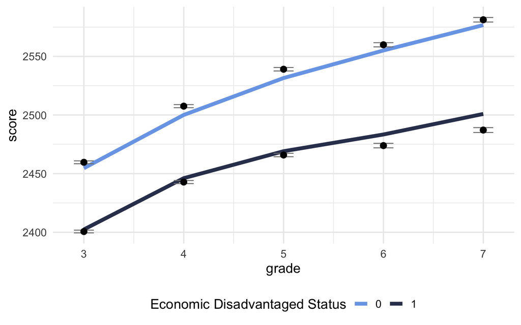

```r
means <- d |>
  group_by(grade, econ_dis_stable) |>
  summarize(
    score = mean(rit_tot, na.rm = TRUE),
    se = sundry::se(rit_tot),
    lower = score + qnorm(0.025) * se,
    upper = score + qnorm(0.975) * se
  )

ggplot(means, aes(grade, score)) +
  geom_line(
    aes(x = wave + 3, y = pred, color = factor(econ_dis_stable)),
    pred_frame,
    size = 2
  ) +
  geom_errorbar(
    aes(ymin = lower, ymax = upper),
    width = 0.2,
    color = "gray50"
  ) +
  geom_point(
    aes(group = factor(econ_dis_stable)),
    size = 3,
  ) +
  scale_color_manual(
    "Economic Disadvantaged Status",
    values = c("#79a6e9", "#333E5C")
  ) +
  theme(legend.position = "bottom")
```

## RQ 3

Initially, I was planning to just extend the previous models, but I’m now realizing that won’t actually address the research question becuase that would correspond to variability in the effect of absenteeism on achievement, rather than variability in absenteeism rates. To actually address our research question, we’ll need to fit a model with absenteeism as the outcome.

Let’s look at the distribution of absenteeism to see if we need to model it as a count distribution or if we can get away with assuming a gaussian distribution.

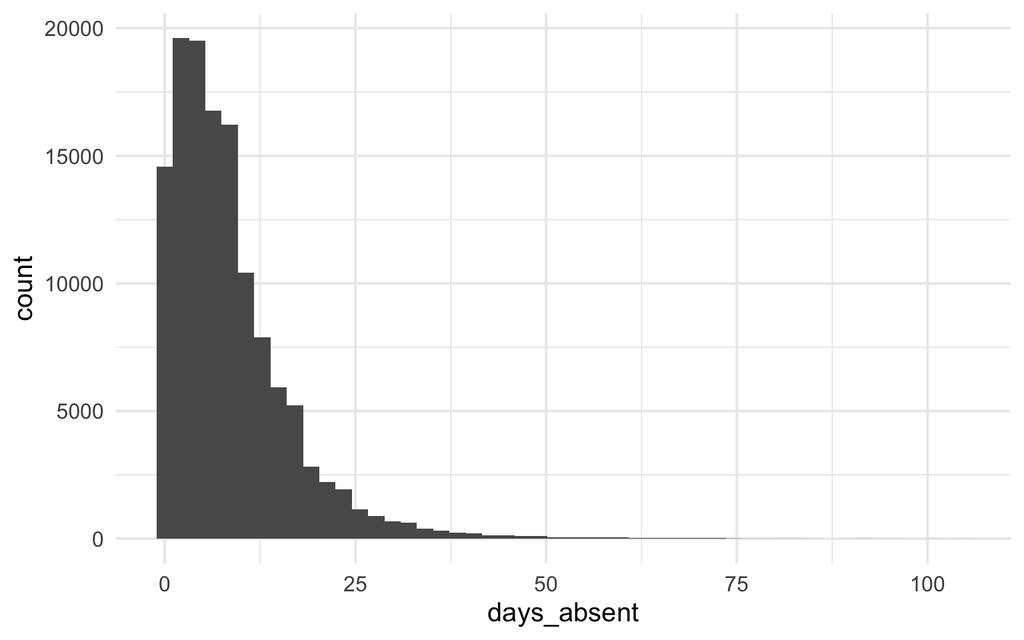

```r
ggplot(d, aes(days_absent)) +
  geom_histogram(bins = 50)
```

Well… it seems to be pretty classically following the count distribution, so we’ll need to go with that. Because we have non-integer data though, I’ll model it assuming a Gamma distribution.

We’ll start by modeling just the between-student and between-school variability in absenteeism.

```r
m0_abs <- glmer(
  days_absent + 1 ~ 1 +
    (1 | ssid) + (1 | schid),
  data = d,
  family = Gamma(link = "log"),
  control = glmerControl(optimizer = "Nelder_Mead")
)

summary(m0_abs)
```

```
## Generalized linear mixed model fit by maximum likelihood (Laplace
##   Approximation) [glmerMod]
##  Family: Gamma  ( log )
## Formula: days_absent + 1 ~ 1 + (1 | ssid) + (1 | schid)
##    Data: d
## Control: glmerControl(optimizer = "Nelder_Mead")
##
##       AIC       BIC    logLik  deviance  df.resid
##  748362.4  748401.5 -374177.2  748354.4    128484
##
## Scaled residuals:
##     Min      1Q  Median      3Q     Max
## -1.7997 -0.6182 -0.0501  0.5424  7.0446
##
## Random effects:
##  Groups   Name        Variance Std.Dev.
##  ssid     (Intercept) 0.24658  0.4966
##  schid    (Intercept) 0.02069  0.1438
##  Residual             0.28597  0.5348
## Number of obs: 128488, groups:  ssid, 39797; schid, 649
##
## Fixed effects:
##             Estimate Std. Error t value Pr(>|z|)
## (Intercept)  1.99318    0.01098   181.5   <2e-16 ***
## ---
## Signif. codes:  0 '***' 0.001 '**' 0.01 '*' 0.05 '.' 0.1 ' ' 1
```

This model indicates that students were absent, on average, about $exp(1.99) = 7.3155338$ days per year. This varied *a lot* between students. A student one standard deviation below the mean would be expected to miss $exp(1.99 - 0.496) = 4.4548794$ days, while a student one standard deviation above the mean would be expected to be absent $exp(1.99 + 0.496) = 12.0131274$ days. At the school level, there was still pretty considerable variation but, as I think we would expect, not as much as at the individual level. The absenteeism rates in a school one standard deviation below the mean would be expected to average $exp(1.99 - 0.144) = 6.3344311$, whereas a school one standard deviation above would be expected to average $exp(1.99 + 0.144) = 8.4485937$ days absent.

Let’s move on by modeling the trend over time. We’ll fit another unconditional “growth” model with the effect of time (`wave`) randomly varying between students and schools.

```r
m1_abs <- glmer(
  days_absent + 1 ~ wave +
    (wave | ssid) + (wave | schid),
  data = d,
  family = Gamma(link = "log"),
  control = glmerControl(optimizer = "nlminbwrap")
)
summary(m1_abs)
```

```
## Generalized linear mixed model fit by maximum likelihood (Laplace
##   Approximation) [glmerMod]
##  Family: Gamma  ( log )
## Formula: days_absent + 1 ~ wave + (wave | ssid) + (wave | schid)
##    Data: d
## Control: glmerControl(optimizer = "nlminbwrap")
##
##       AIC       BIC    logLik  deviance  df.resid
##  731403.5  731491.4 -365692.7  731385.5    128479
##
## Scaled residuals:
##     Min      1Q  Median      3Q     Max
## -2.0043 -0.5363  0.0040  0.5144  8.0797
##
## Random effects:
##  Groups   Name        Variance Std.Dev. Corr
##  ssid     (Intercept) 0.346113 0.5883
##           wave        0.039909 0.1998   -0.57
##  schid    (Intercept) 0.028173 0.1678
##           wave        0.004109 0.0641   -0.65
##  Residual             0.232159 0.4818
## Number of obs: 128488, groups:  ssid, 39797; schid, 649
##
## Fixed effects:
##             Estimate Std. Error t value Pr(>|z|)
## (Intercept) 1.822962   0.014595 124.906   <2e-16 ***
## wave        0.052065   0.005279   9.864   <2e-16 ***
## ---
## Signif. codes:  0 '***' 0.001 '**' 0.01 '*' 0.05 '.' 0.1 ' ' 1
##
## Correlation of Fixed Effects:
##      (Intr)
## wave -0.642
```

However, this model also assumes linearity. Let’s visualize that quickly to see if a non-linear model might be a better option.

```r
d |>
  group_by(grade) |>
  summarize(mean_absenteeism = mean(days_absent, na.rm = TRUE))
```

```
## # A tibble: 5 x 2
##   grade mean_absenteeism
##   <dbl>            <dbl>
## 1     3         7.877444
## 2     4         7.783204
## 3     5         8.179019
## 4     6         8.964497
## 5     7        10.12149
```

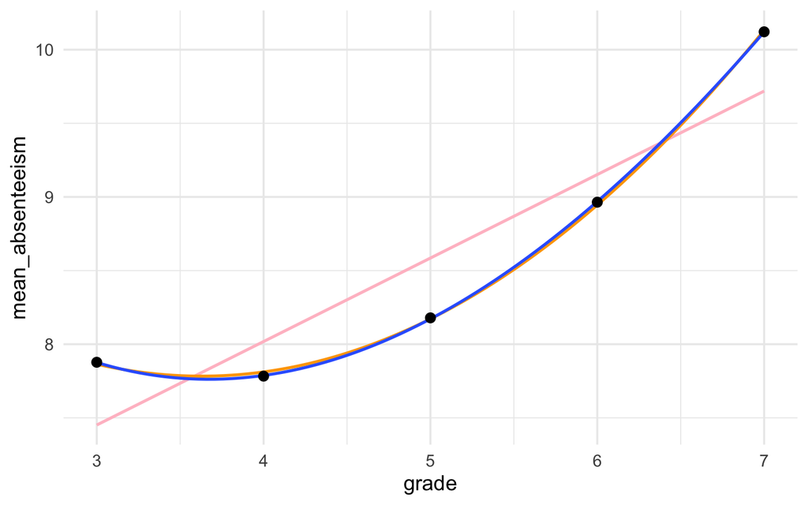

```r
d |>
  group_by(grade) |>
  summarize(mean_absenteeism = mean(days_absent, na.rm = TRUE)) |>
  ggplot(aes(grade, mean_absenteeism)) +
    geom_smooth(
      method = "lm",
      color = "pink",
      se = FALSE
    ) +
      geom_smooth(
        method = "lm",
        color = "orange",
        formula = y ~ poly(x, 2),
        se = FALSE
      ) +
      geom_smooth(
        method = "lm",
        formula = y ~ poly(x, 3),
        se = FALSE
      ) +
      geom_point(size = 3)
```

In this case, it’s looking decidedly non-linear, but it also appears a quadratic slope may adequately describe the relation. Let’s try both and just make sure that the quadratic does fit better than the linear, but not better than a cubic.

```r
m1b_abs <- glmer(
  days_absent + 1 ~ poly(wave, 2) +
    (wave | ssid) + (wave | schid),
  data = d,
  family = Gamma(link = "log"),
  control = glmerControl(
    optimizer = "nloptwrap",
    optCtrl = list(algorithm = "NLOPT_LN_BOBYQA")
  )
)
anova(m1_abs, m1b_abs)
```

```
## Data: d
## Models:
## m1_abs: days_absent + 1 ~ wave + (wave | ssid) + (wave | schid)
## m1b_abs: days_absent + 1 ~ poly(wave, 2) + (wave | ssid) + (wave | schid)
##         npar    AIC    BIC  logLik deviance  Chisq Df Pr(>Chisq)
## m1_abs     9 731403 731491 -365693   731385
## m1b_abs   10 731404 731502 -365692   731384 1.2584  1     0.2619
```

And actually, surprisingly to me anyway, even the quadratic is not fitting any better, so we’ll stick with the linear fit.

Next let’s see how this varies by economically disadvantaged status. First, we’ll model the average initial difference.

```r
m2_abs <- glmer(
  days_absent + 1 ~ wave + econ_dis_stable +
    (wave | ssid) + (wave | schid),
  data = d,
  family = Gamma(link = "log"),
  control = glmerControl(optimizer = "nmkbw")
)
summary(m2_abs)
```

```
## Generalized linear mixed model fit by maximum likelihood (Laplace
##   Approximation) [glmerMod]
##  Family: Gamma  ( log )
## Formula: days_absent + 1 ~ wave + econ_dis_stable + (wave | ssid) + (wave |
##     schid)
##    Data: d
## Control: glmerControl(optimizer = "nmkbw")
##
##       AIC       BIC    logLik  deviance  df.resid
##  731062.4  731160.1 -365521.2  731042.4    128478
##
## Scaled residuals:
##     Min      1Q  Median      3Q     Max
## -2.0070 -0.5369  0.0048  0.5169  8.1595
##
## Random effects:
##  Groups   Name        Variance Std.Dev. Corr
##  ssid     (Intercept) 0.342807 0.58550
##           wave        0.039700 0.19925  -0.57
##  schid    (Intercept) 0.027338 0.16534
##           wave        0.004069 0.06379  -0.65
##  Residual             0.231403 0.48104
## Number of obs: 128488, groups:  ssid, 39797; schid, 649
##
## Fixed effects:
##                 Estimate Std. Error t value Pr(>|z|)
## (Intercept)     1.745612   0.015033 116.119   <2e-16 ***
## wave            0.051575   0.005266   9.795   <2e-16 ***
## econ_dis_stable 0.162287   0.008747  18.553   <2e-16 ***
## ---
## Signif. codes:  0 '***' 0.001 '**' 0.01 '*' 0.05 '.' 0.1 ' ' 1
##
## Correlation of Fixed Effects:
##             (Intr) wave
## wave        -0.614
## ecn_ds_stbl -0.279 -0.004
```

We see a pretty big differential, with students who are classified in the economic disadvantaged category being absent 1.18 more days, on average. Let’s see if this this differential changes over time.

```r
m3_abs <- glmer(
  days_absent + 1 ~ wave * econ_dis_stable +
    (wave | ssid) + (wave | schid),
  data = d,
  family = Gamma(link = "log"),
  control = glmerControl(optimizer = "nmkbw")
)
summary(m3_abs)
```

```
## Generalized linear mixed model fit by maximum likelihood (Laplace
##   Approximation) [glmerMod]
##  Family: Gamma  ( log )
## Formula: days_absent + 1 ~ wave * econ_dis_stable + (wave | ssid) + (wave |
##     schid)
##    Data: d
## Control: glmerControl(optimizer = "nmkbw")
##
##       AIC       BIC    logLik  deviance  df.resid
##  731042.4  731149.8 -365510.2  731020.4    128477
##
## Scaled residuals:
##     Min      1Q  Median      3Q     Max
## -2.0072 -0.5371  0.0049  0.5167  8.1668
##
## Random effects:
##  Groups   Name        Variance Std.Dev. Corr
##  ssid     (Intercept) 0.342558 0.5853
##           wave        0.039613 0.1990   -0.57
##  schid    (Intercept) 0.027504 0.1658
##           wave        0.004096 0.0640   -0.65
##  Residual             0.231351 0.4810
## Number of obs: 128488, groups:  ssid, 39797; schid, 649
##
## Fixed effects:
##                      Estimate Std. Error t value Pr(>|z|)
## (Intercept)          1.761383   0.015430 114.152  < 2e-16 ***
## wave                 0.042704   0.005604   7.620 2.54e-14 ***
## econ_dis_stable      0.128766   0.011279  11.416  < 2e-16 ***
## wave:econ_dis_stable 0.018770   0.003988   4.707 2.52e-06 ***
## ---
## Signif. codes:  0 '***' 0.001 '**' 0.01 '*' 0.05 '.' 0.1 ' ' 1
##
## Correlation of Fixed Effects:
##             (Intr) wave   ecn_d_
## wave        -0.639
## ecn_ds_stbl -0.347  0.208
## wv:cn_ds_st  0.216 -0.336 -0.632
```

## Absenteeism as a moderator

### Hasn’t been updated

When adding absenteeism to the model, I followed a similar process as with economic disadvantaged status. This included first adding it as a main effect, then allowing it to vary randomly between schools, then investigating interactions. However, as I mentioned in our meeting on 01/20/2022, Oregon has fairly considerable variation in the number of days schools are open across districts. I therefore started by including this variable (number of days in the school year) as a (standardized) control variable.

```r
m4 <- lmer(
  rit_tot ~ poly(wave, 3) * econ_dis_stable + sy_days_z +
    (wave | ssid) + (wave + econ_dis_stable | schid),
  data = d,
  control = lmerControl(optimizer = "nlminbwrap"),
  REML = FALSE
)
anova(m4, m3b)
```

[output not shown]

The fit of the model is essentially equivalent. We could opt for parsimony here but I’ll keep it in there becuase I think it’s an important control variable for the next step, which is adding in the number of days absent.

In my preliminary modeling, I tried to do what I discussed in the pre-registration, which is standardize it so it has a mean of zero and a standard devaition of 1, but the one standard deviation increase would represent a 5 day increase in days abent (one week). This ended up not working. I got warnings from lme4 about predictors being on very different scales. So I just ended up going with a standard scaling, and we can convert it back to the raw scale to make sense of it, as I’ll illustrate below.

```r
m5 <- lmer(
  rit_tot ~ poly(wave, 3) * econ_dis_stable +
    sy_days_z + days_absent_z +
    (wave | ssid) + (wave + econ_dis_stable | schid),
  data = d,
  control = lmerControl(optimizer = "nlminbwrap"),
  REML = FALSE
)
anova(m4, m5)
```

[output not shown]

And as we would expect, this model actually does fit better.

```r
summary(m5)
```

[output not shown]

Our coefficient states that a one standard deviation increase days absent corresponds to a 5.3 point decrease in students expected scores. We can translate this into a more meaningful metric by dividing the coefficient by the standard deviation of the raw days absent variable, which will put it on the unstandardized scale. This corresponds to

```r
fixef(m5)["days_absent_z"] / sd(d$days_absent)
```

[output not shown]

which implies that a one *day* increase corresponds to an expected decrease in test scores of 0.67 points. So if we want to translate this into our weekly (5 days) value, we can just multiply it by 5.

```r
(fixef(m5)["days_absent_z"] / sd(d$days_absent)) * 5
```

[output not shown]

And we see that this corresponds to an expected 3.36 point decrease.